# Density Estimates

# Estmate Density Using Mean Nearest Neighbor

Load packages and data and functions Most of these are different species lists.

```r
pacman::p_load(here, tidyverse, tidybayes, brms, modelr, furrr, dispRity, patchwork)

here::i_am('Code/Models_Fitted_Variance.Rmd')
```

```
## here() starts at /Users/Dicrostonyx/Library/Mobile Documents/com~apple~CloudDocs/Documents/Projects/Sulawesi/Manuscript/Submission_2_FunEco/Repo
```

```r
#List of species by community
load(here("Species_Data", "Species_Lists.Rdata"))
#List of all species
load(here("Species_Data", "Species_Extant.RData"))

scale2 <- function(x, na.rm = TRUE) (x - mean(x, na.rm = na.rm)) / sd(x, na.rm)
level_order <-  c( 'Bawakaraeng', 'Buliohuto','Dako', "Katopasa", "Ambang", "Latimojong", "Torompupu", "Nokilalaki", "Gandangdewata")
level_order_iso <-  c( 'Bawakaraeng', 'Buliohuto','Dako',  "Ambang", "Latimojong",  "Gandangdewata")

adat <- read_csv(here("All_Traits.csv"))
```

These scripts use the package `furrr` which is a multi-threading version of `purrr`. It incorperates the `futures` package to run on as many cores as you choose. Here I am selecting 6 cores on my laptop.

```r
furrr_options(seed = TRUE)
```

```
## <furrr_options>
```

```r
options(future.rng.onMisuse="ignore")
options(readr.show_col_types = FALSE)
plan(multisession, workers = 6)
```

#### Nearest Neighbor Function

Neighbours function that allows NA’s Edited from https://github.com/TGuillerme/dispRity/blob/61baa826cc965db22c319f4d6e2ffb3550da682d/R/sanitizing.R and https://github.com/TGuillerme/dispRity/blob/f249475f4f7b3f2bd2af00e36a435dacaafaf200/R/dispRity.metric.R

```r
neighbours2 <- function(matrix, which = min, method = "euclidean") {
    ## Check if the matrix is a distance matrix first
    distances <- as.matrix(check.dist.matrix2(matrix, method = method)[[1]])
    ## Remove the diagonals
    diag(distances) <- NA
    ## Get the selected distances for each rows
    return(unname(apply(distances, 1, which, na.rm = TRUE)))
}

check.dist.matrix2 <- function(matrix, method, just.check = FALSE, ...) {

    ## Is distance
    was_dist <- FALSE

    ## Check if distance
    if(is(matrix, "dist")) {
        return(list(matrix, "was_dist" = TRUE))
    }

    ## Is the matrix square?
    if(dim(matrix)[1] == dim(matrix)[2] &&
       all(diag(as.matrix(matrix)) == 0) &&
       all(matrix[upper.tri(matrix)] == matrix[rev(lower.tri(matrix))])) {
        ## It was a distance matrix!
        was_dist <- TRUE
    }

    if(just.check) {
        ## Simply return the check
        return(was_dist)
    } else {
        ## Return a matrix
        if(was_dist) {
            return(list(stats::as.dist(matrix), "was_dist" = TRUE))
        } else {
            return(list(vegan::vegdist(matrix, method = method, na.rm = TRUE, ...), "was_dist" = FALSE))
        }
    }
}
```

```r
get_mnni <- function(data, sp) {
  data %>%
    filter(Species %in% {{sp}}) %>%
  #Split dataframe by draws into 1000 data frames
  split(.$.draw) %>%
  #and then drop the .draw column that defines the groups - FASTER VERSION
  map(., ~ .x[ ,-c(1:2)])  %>%
  # Run the functions......
  map(~ .x %>%
        ### Run the Mean Nearest Neighbor Function (From dispRity)
        neighbours2() %>%
        # then get the mean
        mean()
        ) %>%
  unlist() %>%
  as_tibble()
  }
```

# Cranial Nearest Neighbor

Load the necessary data

```r
cdat <- read_csv(here("Cranial_Data", "Cranial_36axes_Fitted.csv"))
```

#### Broken Stick

Nearest neighbor requires all the axes to be treated the same (unlike what we did in the sum of variance method). Because of this, it isn’t a good idea to use ALL or nearly ALL of the axes, as the nearest neighbor on axis 17 isn’t nearly as biologically meaningful as the nearest neighbor on axis 1 or 2. So we need to do some PC selection. Using the broken stick method from `PCDimension` package:

```r
a = rep(1:36)
#these are the PC variance values for the cranial Procrusted PCA
true = c(0.204147859, 0.147885771, 0.064424297, 0.060399156, 0.043421343, 0.038126757, 0.036660724, 0.033351233, 0.030241809, 0.027281399, 0.023312389, 0.020690302, 0.017886499, 0.016987085, 0.016170664, 0.015161306, 0.014232396, 0.01234345, 0.011657948, 0.0105006, 0.009831498, 0.009525746, 0.009019535, 0.008004607, 0.007836483, 0.007517283, 0.007160749, 0.006919011, 0.00631384, 0.005867241, 0.005440684, 0.005212542, 0.005101055, 0.004628909, 0.004261733, 0.003790978)
expected = PCDimension::brokenStick(1:36, 36)
c_bs = data.frame(a, true, expected)
c_bs
```

```
##     a        true     expected
## 1   1 0.204147859 0.1159599777
## 2   2 0.147885771 0.0881821999
## 3   3 0.064424297 0.0742933110
## 4   4 0.060399156 0.0650340518
## 5   5 0.043421343 0.0580896073
## 6   6 0.038126757 0.0525340518
## 7   7 0.036660724 0.0479044221
## 8   8 0.033351233 0.0439361682
## 9   9 0.030241809 0.0404639459
## 10 10 0.027281399 0.0373775262
## 11 11 0.023312389 0.0345997484
## 12 12 0.020690302 0.0320744959
## 13 13 0.017886499 0.0297596811
## 14 14 0.016987085 0.0276229289
```

[output cut: 22 more lines]

Looking at this, the %variation falls below the expected variation on the 3rd PC

#### Cranial NN Estimate

Estimate Cranial Shape Nearest Neighbor for each community

```r
cf <- cdat %>%
  select(c(Species, .draw, cPC1, cPC2))

amb_nni <- get_mnni(cf, spamb) %>%  mutate(com = "Ambang" )
baw_nni <- get_mnni(cf, spbaw) %>%  mutate(com = "Bawakaraeng" )
bul_nni <- get_mnni(cf, spbul) %>%  mutate(com = "Buliohuto" )
dak_nni <- get_mnni(cf, spdak) %>%  mutate(com = "Dako" )
gan_nni <- get_mnni(cf, spgan) %>%  mutate(com = "Gandangdewata" )
kat_nni <- get_mnni(cf, spkat) %>%  mutate(com = "Katopasa" )
lat_nni <- get_mnni(cf, splat) %>%  mutate(com = "Latimojong" )
nok_nni <- get_mnni(cf, spnok) %>%  mutate(com = "Nokilalaki" )
tor_nni <- get_mnni(cf, sptor) %>%  mutate(com = "Torompupu" )

nn_cran <- bind_rows(amb_nni, baw_nni, bul_nni, dak_nni, gan_nni, kat_nni, lat_nni, nok_nni, tor_nni) %>% rename(c_nn = value)
```

```r
dd <- nn_cran %>% select(c_nn)
adat <- adat  %>% bind_cols(dd)
```

test plot

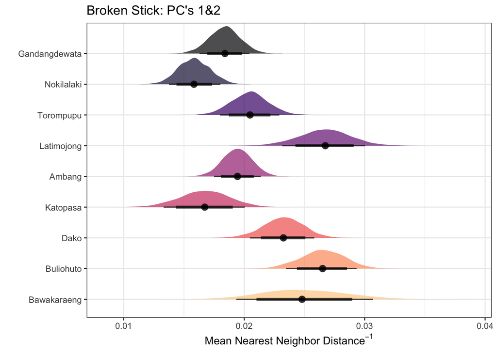

```r
myx <- "Mean Nearest Neighbor Distance"
nn_cran %>%
  mutate(com = factor(com, level = level_order)) %>%
 ggplot(aes(y = factor(com, level = level_order), x =c_nn, fill = com)) +
  stat_halfeye(.width = c(0.74, 0.89),  alpha = 0.7) +
   labs(title="Broken Stick: PC's 1&2", y = "", fill = "Mountain") +
  xlab(bquote(.(myx)^-1)) +
  #xlim(1, 3.2) +
  theme_bw() + scale_fill_viridis_d(direction = -1, begin = 0, end = 0.9, option = "A") + guides(fill = guide_legend(reverse=T)) + theme(legend.position = "none")
```

# Cranial NN - No Scale

The previous way I did this was a work around for dealing with the variance of each PC axis, but turns out that that was only a problem because I was SCALING the data. The natural cumulative variance of each PC axis is intrinsic in the values themselves, so in theory I could do NN analyses without using broken stick.

Lets try that. Going to copy and edit the code above.

```r
#cdat <- read_csv(here("Cranial_Data", "Cranial_36axes_Fitted.csv"))
```

#### NN Estimate

```r
#cf <- cdat %>%
#  select(c(Species, .draw, cPC1:cPC36))
#
#amb_nni <- get_mnni(cf, spamb) %>%  mutate(com = "Ambang" )
#baw_nni <- get_mnni(cf, spbaw) %>%  mutate(com = "Bawakaraeng" )
#bul_nni <- get_mnni(cf, spbul) %>%  mutate(com = "Buliohuto" )
#dak_nni <- get_mnni(cf, spdak) %>%  mutate(com = "Dako" )
#gan_nni <- get_mnni(cf, spgan) %>%  mutate(com = "Gandangdewata" )
#kat_nni <- get_mnni(cf, spkat) %>%  mutate(com = "Katopasa" )
#lat_nni <- get_mnni(cf, splat) %>%  mutate(com = "Latimojong" )
#nok_nni <- get_mnni(cf, spnok) %>%  mutate(com = "Nokilalaki" )
#tor_nni <- get_mnni(cf, sptor) %>%  mutate(com = "Torompupu" )

#nn_cran2 <- bind_rows(amb_nni, baw_nni, bul_nni, dak_nni, gan_nni, kat_nni, lat_nni, nok_nni, tor_nni) %>% rename(c_nn = value)
```

```r
#dd <- nn_cran %>% select(c_nn)
#adat <- adat  %>% bind_cols(dd)
```

# Cranial Size Estimate

```r
cf <- cdat %>%
  select(c(Species, .draw, cCsize))

amb_nni <- get_mnni(cf, spamb) %>%  mutate(com = "Ambang" )
baw_nni <- get_mnni(cf, spbaw) %>%  mutate(com = "Bawakaraeng" )
bul_nni <- get_mnni(cf, spbul) %>%  mutate(com = "Buliohuto" )
dak_nni <- get_mnni(cf, spdak) %>%  mutate(com = "Dako" )
gan_nni <- get_mnni(cf, spgan) %>%  mutate(com = "Gandangdewata" )
kat_nni <- get_mnni(cf, spkat) %>%  mutate(com = "Katopasa" )
lat_nni <- get_mnni(cf, splat) %>%  mutate(com = "Latimojong" )
nok_nni <- get_mnni(cf, spnok) %>%  mutate(com = "Nokilalaki" )
tor_nni <- get_mnni(cf, sptor) %>%  mutate(com = "Torompupu" )


nn_csize <- bind_rows(amb_nni, baw_nni, bul_nni, dak_nni, gan_nni, kat_nni, lat_nni, nok_nni, tor_nni) %>% rename(csize_nn = value)

dd <- nn_csize %>% select(csize_nn)
adat <- adat  %>% bind_cols(dd)
```

# Dentary Nearest Neighbor

```r
ddat <- read_csv(here("Dentary_Data", "Dentary_20axes_Fitted.csv"))
```

#### Broken Stick

```r
a = rep(1:20)
#these are the PC variance values for the dentary Procrustes PCA
true = c(0.2821, 0.1529, 0.1424, 0.0693, 0.0548, 0.0393, 0.0345, 0.0269, 0.0241, 0.0212, 0.0173, 0.0164, 0.0126, 0.0117, 0.0102, 0.0097, 0.0089, 0.0082, 0.0066, 0.0059)
expected = PCDimension::brokenStick(1:20, 20)
d_bs = data.frame(a, true, expected)
d_bs %>% round(digits = 3)
```

```
##     a  true expected
## 1   1 0.282    0.180
## 2   2 0.153    0.130
## 3   3 0.142    0.105
## 4   4 0.069    0.088
## 5   5 0.055    0.076
## 6   6 0.039    0.066
## 7   7 0.034    0.057
## 8   8 0.027    0.050
## 9   9 0.024    0.044
## 10 10 0.021    0.038
## 11 11 0.017    0.033
## 12 12 0.016    0.029
## 13 13 0.013    0.025
## 14 14 0.012    0.021
## 15 15 0.010    0.017
## 16 16 0.010    0.014
## 17 17 0.009    0.011
## 18 18 0.008    0.008
## 19 19 0.007    0.005
## 20 20 0.006    0.002
```

Keep the first 3 PCs of the dentary shape.

#### Dentary NN Estimate

Estimate Dentary Shape Nearest Neighbor for each community

```r
df <- ddat %>%
  select(c(Species, .draw, dPC1, dPC2, dPC3))

amb_nni <- get_mnni(df, spamb) %>%  mutate(com = "Ambang" )
baw_nni <- get_mnni(df, spbaw) %>%  mutate(com = "Bawakaraeng" )
bul_nni <- get_mnni(df, spbul) %>%  mutate(com = "Buliohuto" )
dak_nni <- get_mnni(df, spdak) %>%  mutate(com = "Dako" )
gan_nni <- get_mnni(df, spgan) %>%  mutate(com = "Gandangdewata" )
kat_nni <- get_mnni(df, spkat) %>%  mutate(com = "Katopasa" )
lat_nni <- get_mnni(df, splat) %>%  mutate(com = "Latimojong" )
nok_nni <- get_mnni(df, spnok) %>%  mutate(com = "Nokilalaki" )
tor_nni <- get_mnni(df, sptor) %>%  mutate(com = "Torompupu" )

myx <- "Mean Nearest Neighbor Distance"

nn_dent <- bind_rows(amb_nni, baw_nni, bul_nni, dak_nni, gan_nni, kat_nni, lat_nni, nok_nni, tor_nni) %>% rename(d_nn = value)

dd <- nn_dent %>% select(d_nn)
adat <- adat  %>% bind_cols(dd)
```

## Dentary Size Estimate

```r
df <- ddat %>%
  select(c(Species, .draw, dCsize))

amb_nni <- get_mnni(df, spamb) %>%  mutate(com = "Ambang" )
baw_nni <- get_mnni(df, spbaw) %>%  mutate(com = "Bawakaraeng" )
bul_nni <- get_mnni(df, spbul) %>%  mutate(com = "Buliohuto" )
dak_nni <- get_mnni(df, spdak) %>%  mutate(com = "Dako" )
gan_nni <- get_mnni(df, spgan) %>%  mutate(com = "Gandangdewata" )
kat_nni <- get_mnni(df, spkat) %>%  mutate(com = "Katopasa" )
lat_nni <- get_mnni(df, splat) %>%  mutate(com = "Latimojong" )
nok_nni <- get_mnni(df, spnok) %>%  mutate(com = "Nokilalaki" )
tor_nni <- get_mnni(df, sptor) %>%  mutate(com = "Torompupu" )

nn_dsize <- bind_rows(amb_nni, baw_nni, bul_nni, dak_nni, gan_nni, kat_nni, lat_nni, nok_nni, tor_nni) %>% rename(dsize_nn = value)


dd <- nn_dsize %>% select(dsize_nn)
adat <- adat  %>% bind_cols(dd)
```

#Skull Nearest Neighbor How do I do this?

```r
skdat <- ddat  %>% select(!.row) %>%
  full_join(cdat, by = c(".draw", "Species"))
```

I guess I need to figure a way around the NAs The only issue is the Paucidentomys in Latimojong and Gandang

## Skull NN Estimate

```r
df <- skdat %>%
  select(c(Species, .draw, dPC1, dPC2, dPC3, cPC1, cPC2))

amb_nni <- get_mnni(df, spamb) %>%  mutate(com = "Ambang" )
baw_nni <- get_mnni(df, spbaw) %>%  mutate(com = "Bawakaraeng" )
bul_nni <- get_mnni(df, spbul) %>%  mutate(com = "Buliohuto" )
dak_nni <- get_mnni(df, spdak) %>%  mutate(com = "Dako" )
gan_nni <- get_mnni(df, spgan) %>%  mutate(com = "Gandangdewata" )
kat_nni <- get_mnni(df, spkat) %>%  mutate(com = "Katopasa" )
lat_nni <- get_mnni(df, splat) %>%  mutate(com = "Latimojong" )
nok_nni <- get_mnni(df, spnok) %>%  mutate(com = "Nokilalaki" )
tor_nni <- get_mnni(df, sptor) %>%  mutate(com = "Torompupu" )

nn_sk <- bind_rows(amb_nni, baw_nni, bul_nni, dak_nni, gan_nni, kat_nni, lat_nni, nok_nni, tor_nni) %>% rename(sk_nn = value)

rm(amb_nni, baw_nni, bul_nni, dak_nni, gan_nni, kat_nni, lat_nni, nok_nni, tor_nni)

dd <- nn_sk %>% select(sk_nn)
adat <- adat %>% bind_cols(dd)
```

# External Measurements

```r
edat <- read_csv(here("External_Measurement_Data", "External_Fitted.csv"))
```

## Head-Body NN

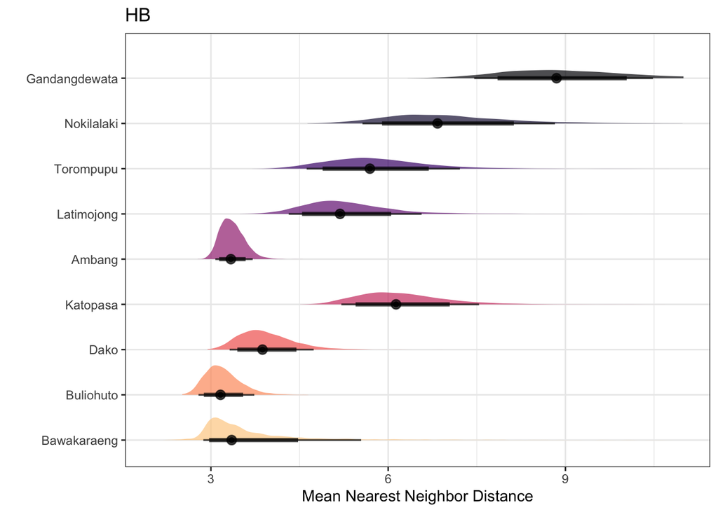

```r
df <- edat %>%
  select(c(Species, .draw, HB))

amb_nni <- get_mnni(df, spamb) %>%  mutate(com = "Ambang" )
baw_nni <- get_mnni(df, spbaw) %>%  mutate(com = "Bawakaraeng" )
bul_nni <- get_mnni(df, spbul) %>%  mutate(com = "Buliohuto" )
dak_nni <- get_mnni(df, spdak) %>%  mutate(com = "Dako" )
gan_nni <- get_mnni(df, spgan) %>%  mutate(com = "Gandangdewata" )
kat_nni <- get_mnni(df, spkat) %>%  mutate(com = "Katopasa" )
lat_nni <- get_mnni(df, splat) %>%  mutate(com = "Latimojong" )
nok_nni <- get_mnni(df, spnok) %>%  mutate(com = "Nokilalaki" )
tor_nni <- get_mnni(df, sptor) %>%  mutate(com = "Torompupu" )

nn_HB <- bind_rows(amb_nni, baw_nni, bul_nni, dak_nni, gan_nni, kat_nni, lat_nni, nok_nni, tor_nni) %>% rename(HB_nn = value)

dd <- nn_HB %>% select(HB_nn)
adat <- adat %>% bind_cols(dd)

nn_HB %>%
  mutate(com = factor(com, level = level_order)) %>%
 ggplot(aes(y = factor(com, level = level_order), x = 1/HB_nn, fill = com)) +
  stat_halfeye(.width = c(0.74, 0.89),  alpha = 0.7) +
   labs(title="HB",x="Mean Nearest Neighbor Distance", y = "", fill = "Mountain") +
  xlim(2, 11) +
  theme_bw() + scale_fill_viridis_d(direction = -1, begin = 0, end = 0.9, option = "A") + guides(fill = guide_legend(reverse=T)) + theme(legend.position = "none")
```

## Tail NN

```r
df <- edat %>%
  select(c(Species, .draw, rTail))

amb_nni <- get_mnni(df, spamb) %>%  mutate(com = "Ambang" )
baw_nni <- get_mnni(df, spbaw) %>%  mutate(com = "Bawakaraeng" )
bul_nni <- get_mnni(df, spbul) %>%  mutate(com = "Buliohuto" )
dak_nni <- get_mnni(df, spdak) %>%  mutate(com = "Dako" )
gan_nni <- get_mnni(df, spgan) %>%  mutate(com = "Gandangdewata" )
kat_nni <- get_mnni(df, spkat) %>%  mutate(com = "Katopasa" )
lat_nni <- get_mnni(df, splat) %>%  mutate(com = "Latimojong" )
nok_nni <- get_mnni(df, spnok) %>%  mutate(com = "Nokilalaki" )
tor_nni <- get_mnni(df, sptor) %>%  mutate(com = "Torompupu" )

nn_Tail <- bind_rows(amb_nni, baw_nni, bul_nni, dak_nni, gan_nni, kat_nni, lat_nni, nok_nni, tor_nni) %>% rename(Tail_nn = value)

dd <- nn_Tail %>% select(Tail_nn)
adat <- adat %>% bind_cols(dd)
```

## HF NN

```r
df <- edat %>%
  select(c(Species, .draw, rHF))

amb_nni <- get_mnni(df, spamb) %>%  mutate(com = "Ambang" )
baw_nni <- get_mnni(df, spbaw) %>%  mutate(com = "Bawakaraeng" )
bul_nni <- get_mnni(df, spbul) %>%  mutate(com = "Buliohuto" )
dak_nni <- get_mnni(df, spdak) %>%  mutate(com = "Dako" )
gan_nni <- get_mnni(df, spgan) %>%  mutate(com = "Gandangdewata" )
kat_nni <- get_mnni(df, spkat) %>%  mutate(com = "Katopasa" )
lat_nni <- get_mnni(df, splat) %>%  mutate(com = "Latimojong" )
nok_nni <- get_mnni(df, spnok) %>%  mutate(com = "Nokilalaki" )
tor_nni <- get_mnni(df, sptor) %>%  mutate(com = "Torompupu" )

nn_HF <- bind_rows(amb_nni, baw_nni, bul_nni, dak_nni, gan_nni, kat_nni, lat_nni, nok_nni, tor_nni) %>% rename(HF_nn = value)

dd <- nn_HF %>% select(HF_nn)
adat <- adat %>% bind_cols(dd)
```

## Ear NN

```r
df <- edat %>%
  select(c(Species, .draw, rEar))

amb_nni <- get_mnni(df, spamb) %>%  mutate(com = "Ambang" )
baw_nni <- get_mnni(df, spbaw) %>%  mutate(com = "Bawakaraeng" )
bul_nni <- get_mnni(df, spbul) %>%  mutate(com = "Buliohuto" )
dak_nni <- get_mnni(df, spdak) %>%  mutate(com = "Dako" )
gan_nni <- get_mnni(df, spgan) %>%  mutate(com = "Gandangdewata" )
kat_nni <- get_mnni(df, spkat) %>%  mutate(com = "Katopasa" )
lat_nni <- get_mnni(df, splat) %>%  mutate(com = "Latimojong" )
nok_nni <- get_mnni(df, spnok) %>%  mutate(com = "Nokilalaki" )
tor_nni <- get_mnni(df, sptor) %>%  mutate(com = "Torompupu" )

nn_Ear <- bind_rows(amb_nni, baw_nni, bul_nni, dak_nni, gan_nni, kat_nni, lat_nni, nok_nni, tor_nni) %>% rename(Ear_nn = value)

dd <- nn_Ear %>% select(Ear_nn)
adat <- adat %>% bind_cols(dd)
```

## Mass NN

```r
df <- edat %>%
  select(c(Species, .draw, lMass))

amb_nni <- get_mnni(df, spamb) %>%  mutate(com = "Ambang" )
baw_nni <- get_mnni(df, spbaw) %>%  mutate(com = "Bawakaraeng" )
bul_nni <- get_mnni(df, spbul) %>%  mutate(com = "Buliohuto" )
dak_nni <- get_mnni(df, spdak) %>%  mutate(com = "Dako" )
gan_nni <- get_mnni(df, spgan) %>%  mutate(com = "Gandangdewata" )
kat_nni <- get_mnni(df, spkat) %>%  mutate(com = "Katopasa" )
lat_nni <- get_mnni(df, splat) %>%  mutate(com = "Latimojong" )
nok_nni <- get_mnni(df, spnok) %>%  mutate(com = "Nokilalaki" )
tor_nni <- get_mnni(df, sptor) %>%  mutate(com = "Torompupu" )

nn_Mass <- bind_rows(amb_nni, baw_nni, bul_nni, dak_nni, gan_nni, kat_nni, lat_nni, nok_nni, tor_nni) %>% rename(Mass_nn = value)

dd <- nn_Mass %>% select(Mass_nn)
adat <- adat %>% bind_cols(dd)
```

## Bsz NN

```r
df <- edat %>%
  select(c(Species, .draw, lMass, HB))

amb_nni <- get_mnni(df, spamb) %>%  mutate(com = "Ambang" )
baw_nni <- get_mnni(df, spbaw) %>%  mutate(com = "Bawakaraeng" )
bul_nni <- get_mnni(df, spbul) %>%  mutate(com = "Buliohuto" )
dak_nni <- get_mnni(df, spdak) %>%  mutate(com = "Dako" )
gan_nni <- get_mnni(df, spgan) %>%  mutate(com = "Gandangdewata" )
kat_nni <- get_mnni(df, spkat) %>%  mutate(com = "Katopasa" )
lat_nni <- get_mnni(df, splat) %>%  mutate(com = "Latimojong" )
nok_nni <- get_mnni(df, spnok) %>%  mutate(com = "Nokilalaki" )
tor_nni <- get_mnni(df, sptor) %>%  mutate(com = "Torompupu" )

nn_Bsz <- bind_rows(amb_nni, baw_nni, bul_nni, dak_nni, gan_nni, kat_nni, lat_nni, nok_nni, tor_nni) %>% rename(Bsz_nn = value)

dd <- nn_Bsz %>% select(Bsz_nn)
adat <- adat %>% bind_cols(dd)
```

## All External NN

```r
df <- edat %>%
  select(c(Species, .draw, HB, rTail, rHF, rEar, lMass))

amb_nni <- get_mnni(df, spamb) %>%  mutate(com = "Ambang" )
baw_nni <- get_mnni(df, spbaw) %>%  mutate(com = "Bawakaraeng" )
bul_nni <- get_mnni(df, spbul) %>%  mutate(com = "Buliohuto" )
dak_nni <- get_mnni(df, spdak) %>%  mutate(com = "Dako" )
gan_nni <- get_mnni(df, spgan) %>%  mutate(com = "Gandangdewata" )
kat_nni <- get_mnni(df, spkat) %>%  mutate(com = "Katopasa" )
lat_nni <- get_mnni(df, splat) %>%  mutate(com = "Latimojong" )
nok_nni <- get_mnni(df, spnok) %>%  mutate(com = "Nokilalaki" )
tor_nni <- get_mnni(df, sptor) %>%  mutate(com = "Torompupu" )

nn_ext <- bind_rows(amb_nni, baw_nni, bul_nni, dak_nni, gan_nni, kat_nni, lat_nni, nok_nni, tor_nni) %>% rename(ext_nn = value)

dd <- nn_ext %>% select(ext_nn)
adat <- adat %>% bind_cols(dd)
```

# Morpho NN

This is skull shape and external measurements hb, tail, hf, lmass, ear

```r
morph_dat <-  skdat  %>% select(!.row) %>% select(Species, .draw, dPC1, dPC2, dPC3, cPC1, cPC2) %>%
  full_join(edat, by = c(".draw", "Species"))


df <- morph_dat %>%
  select(!.row)

amb_nni <- get_mnni(df, spamb) %>%  mutate(com = "Ambang" )
baw_nni <- get_mnni(df, spbaw) %>%  mutate(com = "Bawakaraeng" )
bul_nni <- get_mnni(df, spbul) %>%  mutate(com = "Buliohuto" )
dak_nni <- get_mnni(df, spdak) %>%  mutate(com = "Dako" )
gan_nni <- get_mnni(df, spgan) %>%  mutate(com = "Gandangdewata" )
kat_nni <- get_mnni(df, spkat) %>%  mutate(com = "Katopasa" )
lat_nni <- get_mnni(df, splat) %>%  mutate(com = "Latimojong" )
nok_nni <- get_mnni(df, spnok) %>%  mutate(com = "Nokilalaki" )
tor_nni <- get_mnni(df, sptor) %>%  mutate(com = "Torompupu" )

nn_morph <- bind_rows(amb_nni, baw_nni, bul_nni, dak_nni, gan_nni, kat_nni, lat_nni, nok_nni, tor_nni) %>% rename(morpho_nn = value)

dd <- nn_morph %>% select(morpho_nn)
adat <- adat %>% bind_cols(dd)


rm(amb_nni, baw_nni, bul_nni, dak_nni, gan_nni, kat_nni, lat_nni, nok_nni, tor_nni)
```

```r
adat %>% write_csv(here("All_Traits.csv"))
```

# Isotope GROUP Nearest Neighbor

Realized I have to use the grouping data again. Thats ok. It’ll be just like any of the other variables. ## N15 Group

```r
idat <- read_csv(here("Isotope_Data", "Isotope_Group_Level_Fitted.csv")) %>% select(Species, .draw, sN15)


amb_nni <- get_mnni(idat, spamb) %>%  mutate(com = "Ambang" )
baw_nni <- get_mnni(idat, spbaw) %>%  mutate(com = "Bawakaraeng" )
bul_nni <- get_mnni(idat, spbul) %>%  mutate(com = "Buliohuto" )
dak_nni <- get_mnni(idat, spdak) %>%  mutate(com = "Dako" )
gan_nni <- get_mnni(idat, spgan) %>%  mutate(com = "Gandangdewata" )
#kat_nni <- get_mnni(idat, spkat) %>%  mutate(com = "Katopasa" )
lat_nni <- get_mnni(idat, splat) %>%  mutate(com = "Latimojong" )
#nok_nni <- get_mnni(idat, spnok) %>%  mutate(com = "Nokilalaki" )
#tor_nni <- get_mnni(idat, sptor) %>%  mutate(com = "Torompupu" )


nn_N <- bind_rows(amb_nni, baw_nni, bul_nni, dak_nni, gan_nni, lat_nni) %>% rename(N15_nn = value) %>% mutate(.draw = rep(1:4000, 6))

adat <- adat  %>%
  full_join(nn_N, by = c(".draw", "com"))
```

## C13 Group

```r
idat <- read_csv(here("Isotope_Data", "Isotope_Group_Level_Fitted.csv")) %>% select(Species, .draw, sC13)


amb_nni <- get_mnni(idat, spamb) %>%  mutate(com = "Ambang" )
baw_nni <- get_mnni(idat, spbaw) %>%  mutate(com = "Bawakaraeng" )
bul_nni <- get_mnni(idat, spbul) %>%  mutate(com = "Buliohuto" )
dak_nni <- get_mnni(idat, spdak) %>%  mutate(com = "Dako" )
gan_nni <- get_mnni(idat, spgan) %>%  mutate(com = "Gandangdewata" )
#kat_nni <- get_mnni(idat, spkat) %>%  mutate(com = "Katopasa" )
lat_nni <- get_mnni(idat, splat) %>%  mutate(com = "Latimojong" )
#nok_nni <- get_mnni(idat, spnok) %>%  mutate(com = "Nokilalaki" )
#tor_nni <- get_mnni(idat, sptor) %>%  mutate(com = "Torompupu" )


nn_C <- bind_rows(amb_nni, baw_nni, bul_nni, dak_nni, gan_nni, lat_nni) %>% rename(C13_nn = value) %>% mutate(.draw = rep(1:4000, 6))

adat <- adat  %>%
  full_join(nn_C, by = c(".draw", "com"))
```

## Iso Group

```r
idat <- read_csv(here("Isotope_Data", "Isotope_Group_Level_Fitted.csv")) %>% select(Species, .draw, sC13, sN15)


amb_nni <- get_mnni(idat, spamb) %>%  mutate(com = "Ambang" )
baw_nni <- get_mnni(idat, spbaw) %>%  mutate(com = "Bawakaraeng" )
bul_nni <- get_mnni(idat, spbul) %>%  mutate(com = "Buliohuto" )
dak_nni <- get_mnni(idat, spdak) %>%  mutate(com = "Dako" )
gan_nni <- get_mnni(idat, spgan) %>%  mutate(com = "Gandangdewata" )
#kat_nni <- get_mnni(idat, spkat) %>%  mutate(com = "Katopasa" )
lat_nni <- get_mnni(idat, splat) %>%  mutate(com = "Latimojong" )
#nok_nni <- get_mnni(idat, spnok) %>%  mutate(com = "Nokilalaki" )
#tor_nni <- get_mnni(idat, sptor) %>%  mutate(com = "Torompupu" )


nn_i <- bind_rows(amb_nni, baw_nni, bul_nni, dak_nni, gan_nni, lat_nni) %>% rename(iso_nn = value) %>% mutate(.draw = rep(1:4000, 6))

adat <- adat  %>%
  full_join(nn_i, by = c(".draw", "com"))
```

#Write All Data

```r
adat %>% write_csv(here("All_Traits.csv"))
```